# Aula 10 Estimadores

MAE5911 - Aula 10 - Análise de Estimadores via Funções de Estimação

## 1. Fundamentos Teóricos: Funções de Estimação

### Definição Canônica (Definição 2.4.3)

Seja $Z_1, ..., Z_n$ uma sequência de vetores aleatórios. Uma **função de estimação não-viesada** para o parâmetro $\theta \in \Theta \subseteq \mathbb{R}^p$ é definida como:

$$U_n(\theta) = \frac{1}{n}\sum_{k=1}^{n}u_k(Z_k, \theta)$$

$$E_{P_{\theta}}(u_k(Z_k, \theta)) = 0, \quad \forall \theta \in \Theta$$

O estimador $\hat{\theta}_n$ é então definido como a raiz da função de estimação, ou seja, o valor que a anula:

$$U_n(\hat{\theta}_n) = 0$$

## 2. O Método de Momentos (EMM) como Função de Estimação

Para o j-ésimo momento, a função $u_k$ é definida como a diferença entre a variável aleatória elevada à potência $j$ e o seu respectivo momento populacional:

$$u_k(Z_k, \theta) = Z_k^j - h_j(\theta), \quad \text{onde } h_j(\theta) = E_{\theta}(Z^j)$$

### Estudo de Caso: A Distribuição de Poisson

Vamos considerar uma amostra aleatória $Z_1, ..., Z_n$ de uma população $Z \sim \text{Pois}(\theta)$, onde $\theta > 0$. Para esta distribuição, os dois primeiros momentos populacionais são:

1. **Primeiro Momento:** $E_{\theta}(Z) = \theta$
2. **Segundo Momento:** $E_{\theta}(Z^2) = \text{Var}_{\theta}(Z) + [E_{\theta}(Z)]^2 = \theta + \theta^2$

A partir desses momentos, podemos construir dois estimadores diferentes para $\theta$.

#### Estimador 1: EMM1 (baseado no 1º momento)

A função de estimação é: $U_{n,1}(\theta) = \frac{1}{n}\sum_{k=1}^{n}(Z_k - \theta)$

Resolvendo $U_{n,1}(\hat{\theta}_1) = 0$, obtemos: $\frac{1}{n}\sum Z_k - \hat{\theta}_1 = 0 \implies \hat{\theta}_1 = \overline{Z}$

#### Estimador 2: EMM2 (baseado no 2º momento)

A função de estimação é: $U_{n,2}(\theta) = \frac{1}{n}\sum_{k=1}^{n}(Z_k^2 - (\theta + \theta^2))$

Resolvendo $U_{n,2}(\hat{\theta}_2) = 0$, obtemos: $\frac{1}{n}\sum Z_k^2 - (\hat{\theta}_2 + \hat{\theta}_2^2) = 0 \implies \hat{\theta}_2^2 + \hat{\theta}_2 - \overline{Z^2} = 0$

Esta é uma equação quadrática em $\hat{\theta}_2$. Usando a fórmula de Bhaskara e sabendo que $\theta > 0$, pegamos a raiz positiva: $$\hat{\theta}_2 = \frac{-1 + \sqrt{1 + 4\overline{Z^2}}}{2}$$

Temos agora dois estimadores diferentes para o mesmo parâmetro $\theta$. Qual deles é melhor?

## 3. Comparando Estimadores: O Erro Quadrático Médio (EQM)

$$EQM_{\theta}(T(Z_n), g(\theta)) = E_{\theta}[(T(Z_n) - g(\theta))^2]$$

Vamos usar uma simulação de Monte Carlo para *estimar* o EQM de $\hat{\theta}_1$ e $\hat{\theta}_2$ e determinar qual é o melhor na prática.

## 4. Simulação de Monte Carlo em R

O objetivo da simulação é gerar muitas amostras de uma população de Poisson com um $\theta$ conhecido (que chamaremos de `theta0`), calcular as duas estimativas ($\hat{\theta}_1$ e $\hat{\theta}_2$) para cada amostra, e então calcular a média dos erros quadrados para estimar o EQM.

```r
# Definição dos parâmetros da simulação
set.seed(42)  # Garante a reprodutibilidade dos resultados
n = 100       # Tamanho amostral
M = 10000     # Número de réplicas de Monte Carlo
theta0 = 10   # O verdadeiro valor de theta

# Vetores para armazenar as estimativas
theta1_vetor = numeric(M)
theta2_vetor = numeric(M)

# 3. Loop de Simulação
for (i in 1:M) {
  # Gerar uma amostra de uma população Pois(theta0) de tamanho n
  z = rpois(n, theta0)

  # Calcular e armazenar a estimativa de theta1 (EMM1 / EMV)
  theta1_vetor[i] = mean(z)

  # Calcular e armazenar a estimativa de theta2 (EMM2)
  media_z_quadrado = mean(z^2)
  theta2_vetor[i] = (sqrt(4 * media_z_quadrado + 1) - 1) / 2
}

# 4. Cálculo do EQM estimado para cada estimador
# EQM é a média dos erros quadrados
EQM1 = mean((theta1_vetor - theta0)^2)
EQM2 = mean((theta2_vetor - theta0)^2)

# 5. Apresentação dos resultados
cat("Resultado da Simulação de Monte Carlo\n")
cat("---------------------------------------\n")
cat("Tamanho da Amostra (n):", n, "\n")
cat("Número de Réplicas (M):", M, "\n")
cat("Valor Verdadeiro (theta0):", theta0, "\n\n")
cat("EQM estimado para theta1 (Média Amostral):", EQM1, "\n")
cat("EQM estimado para theta2 (2º Momento):", EQM2, "\n")
```

```
Resultado da Simulação de Monte Carlo
---------------------------------------
Tamanho da Amostra (n): 100
Número de Réplicas (M): 10000
Valor Verdadeiro (theta0): 10

EQM estimado para theta1 (Média Amostral): 0.1021638
EQM estimado para theta2 (2º Momento): 0.1072795
```

## 5. Análise dos Resultados e Visualização

Podemos visualizar as distribuições amostrais dos dois estimadores para entender por que isso acontece. Um estimador melhor terá uma distribuição mais concentrada em torno do valor verdadeiro (`theta0 = 10`).

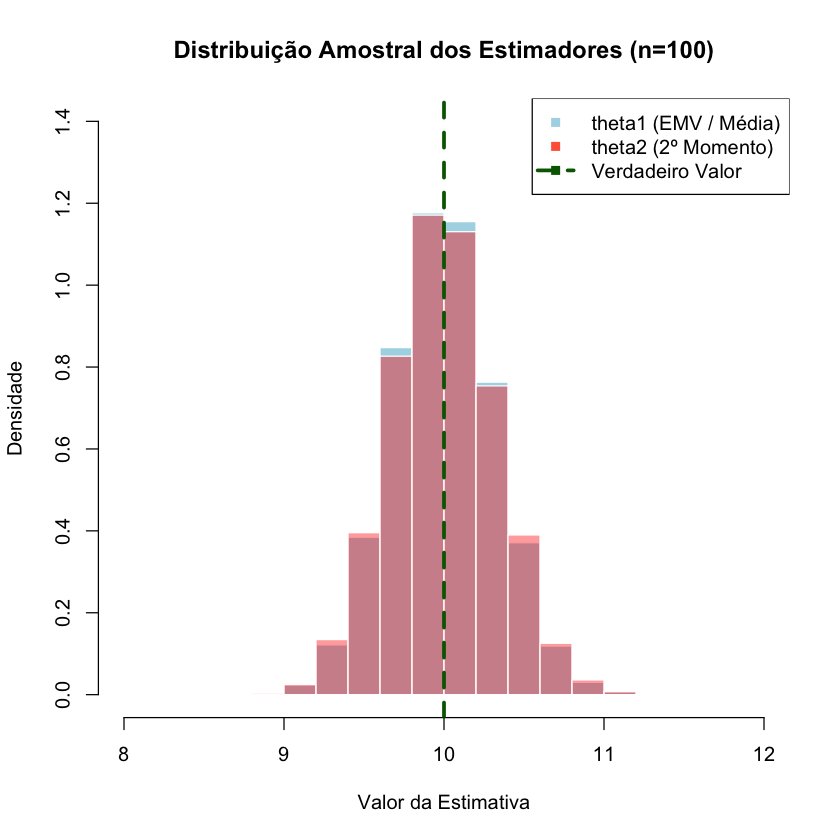

```r
# Gerando os histogramas para comparar as distribuições
hist(theta1_vetor,
     prob = TRUE,
     main = "Distribuição Amostral dos Estimadores (n=100)",
     xlab = "Valor da Estimativa",
     ylab = "Densidade",
     col = "lightblue",
     border = "white",
     xlim = c(8, 12),
     ylim = c(0, 1.4))

# Adicionando o histograma de theta2 sobreposto
hist(theta2_vetor,
     prob = TRUE,
     col = rgb(1, 0, 0, 0.4), # Vermelho semitransparente ("tomato")
     border = "white",
     add = TRUE)

# Adicionando uma linha vertical no valor verdadeiro
abline(v = theta0, col = "darkgreen", lwd = 3, lty = 2)

# Legenda
legend("topright",
       legend = c("theta1 (EMV / Média)", "theta2 (2º Momento)", "Verdadeiro Valor"),
       col = c("lightblue", "tomato", "darkgreen"),
       pch = 15,
       lty = c(NA, NA, 2),
       lwd = c(NA, NA, 3))
```

## Conclusão

Isso ilustra como a teoria (propriedades assintóticas) e a prática (simulações de Monte Carlo) se complementam para validar e comparar procedimentos estatísticos.

## 6. Análise Assintótica e Verificação do Teorema do Limite Central (TLC)

Na seção anterior, vimos empiricamente que $\hat{\theta}_1$ teve um EQM menor que $\hat{\theta}_2$ para $n=100$. A análise assintótica nos ajuda a entender o comportamento desses estimadores quando o tamanho da amostra $n \to \infty$. O **Teorema do Limite Central para Estimadores (Teorema 2.4.1)** é a ferramenta fundamental para isso.

### Teoria: A Distribuição Assintótica dos Estimadores

Conforme suas anotações, podemos aplicar o TLC para encontrar a distribuição assintótica de ambos os estimadores.

#### Estimador 1: $\hat{\theta}_{n,1} = \overline{Z}$

Para o primeiro estimador, o TLC clássico se aplica diretamente: $$\sqrt{n}(\hat{\theta}_{n,1} - \theta) = \sqrt{n}(\overline{Z} - \theta) \xrightarrow{D} N_1(0, \text{Var}_{\theta}(Z))$$ Como para a Poisson temos $\text{Var}_{\theta}(Z) = \theta$, o resultado é: $$\sqrt{n}(\hat{\theta}_{n,1} - \theta) \xrightarrow{D} N_1(0, \theta)$$

#### Estimador 2: $\hat{\theta}_{n,2}$

Para o segundo estimador, a derivação da variância assintótica é mais complexa. Ela envolve o cálculo da variância de $Z^2$, que por sua vez requer o 3º e 4º momentos da Poisson. Como calculado em suas anotações, a variância de $Z^2$ é $\text{Var}_{\theta}(Z^2) = 4\theta^3 + 6\theta^2 + \theta$. A aplicação do Método Delta leva ao resultado: $$\sqrt{n}(\hat{\theta}_{n,2} - \theta) \xrightarrow{D} N_1\left(0, \frac{4\theta^3+6\theta^2+\theta}{(1+2\theta)^2}\right)$$

A variância assintótica do EMV/EMM1, que é $\theta$, é a menor variância possível (atinge o limite de Cramér-Rao). Isso explica teoricamente por que ele é mais eficiente e por que observamos um EQM menor na simulação.

### Simulação: Verificando o TLC

O objetivo agora é usar uma simulação de Monte Carlo para **verificar visualmente** se as distribuições dos estimadores, quando devidamente padronizados, se aproximam de uma Normal Padrão $N(0,1)$, como prevê a teoria.

Para padronizar, usamos a fórmula: $$Z_{norm} = \frac{\sqrt{n}(\hat{\theta}_n - \theta_0)}{\sqrt{\text{Variância Assintótica Teórica}}}$$

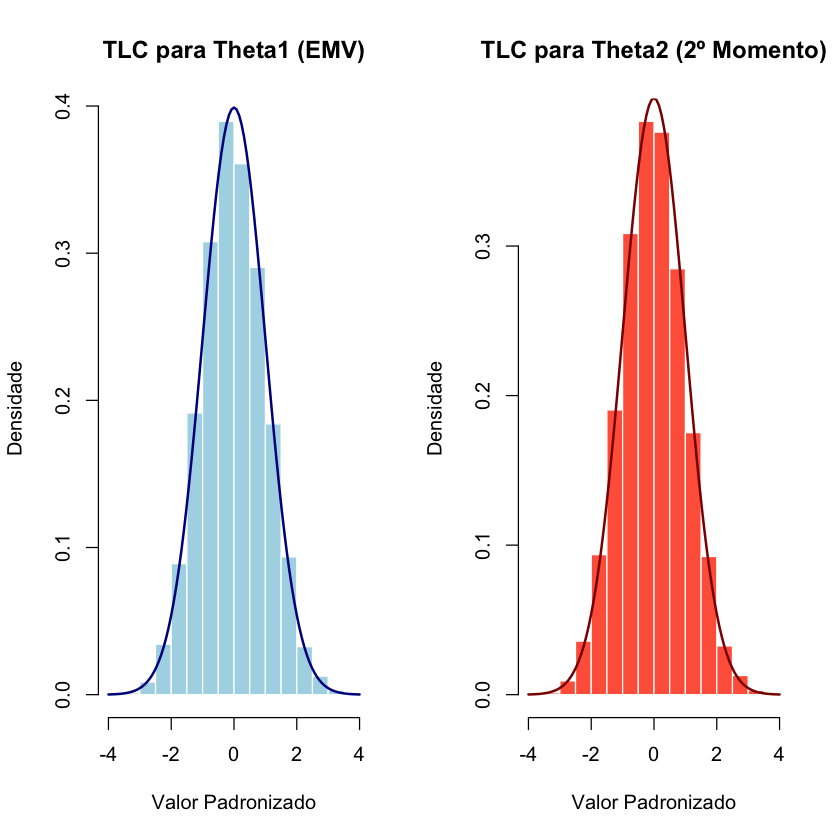

```r
# 1. Parâmetros da simulação (os mesmos de antes)
set.seed(42)
n = 100
M = 10000
theta0 = 10

# 2. Re-executamos a simulação para ter os vetores de estimativas
# (este código é o mesmo da Seção 4)
theta1_vetor = numeric(M)
theta2_vetor = numeric(M)

for (j in 1:M) {
  z = rpois(n, theta0)
  theta1_vetor[j] = mean(z)
  media_z_quadrado = mean(z^2)
  theta2_vetor[j] = (sqrt(4 * media_z_quadrado + 1) - 1) / 2
}

# 3. Cálculo das variâncias assintóticas teóricas usando theta0
var_assint_1 = theta0
var_assint_2 = (4*theta0^3 + 6*theta0^2 + theta0) / (1 + 2*theta0)^2

# 4. Padronização dos estimadores
z1_norm = sqrt(n) * (theta1_vetor - theta0) / sqrt(var_assint_1)
z2_norm = sqrt(n) * (theta2_vetor - theta0) / sqrt(var_assint_2)

# 5. Visualização
# Configura o layout para plotar 2 gráficos lado a lado
par(mfrow = c(1, 2))

# Histograma para o estimador 1 padronizado
hist(z1_norm,
     prob = TRUE,
     main = "TLC para Theta1 (EMV)",
     xlab = "Valor Padronizado",
     ylab = "Densidade",
     col = "lightblue",
     border = "white",
     breaks = 20)
# Adiciona a curva da Normal(0,1) teórica
curve(dnorm(x, 0, 1), add = TRUE, col = "darkblue", lwd = 2)

# Histograma para o estimador 2 padronizado
hist(z2_norm,
     prob = TRUE,
     main = "TLC para Theta2 (2º Momento)",
     xlab = "Valor Padronizado",
     ylab = "Densidade",
     col = "tomato",
     border = "white",
     breaks = 20)
# Adiciona a curva da Normal(0,1) teórica
curve(dnorm(x, 0, 1), add = TRUE, col = "darkred", lwd = 2)
```

**Análise dos Gráficos:** Os histogramas das distribuições empíricas dos estimadores padronizados se ajustam muito bem à curva de densidade da Normal Padrão (em azul escuro e vermelho escuro). Isso é uma **comprovação via simulação** de que a teoria assintótica do TLC, derivada em suas anotações, descreve com precisão o comportamento dos estimadores para um tamanho amostral de $n=100$.

## 7. Análise de Desempenho em um "Grid" de Parâmetros

Uma questão importante é se a superioridade do estimador $\hat{\theta}_1$ se mantém para outros valores de $\theta$. Para investigar isso, podemos calcular o EQM dos estimadores sobre um **grid** (uma sequência) de valores de `theta0`.

```
Iniciando simulação no Grid...
Simulação no Grid concluída.
```

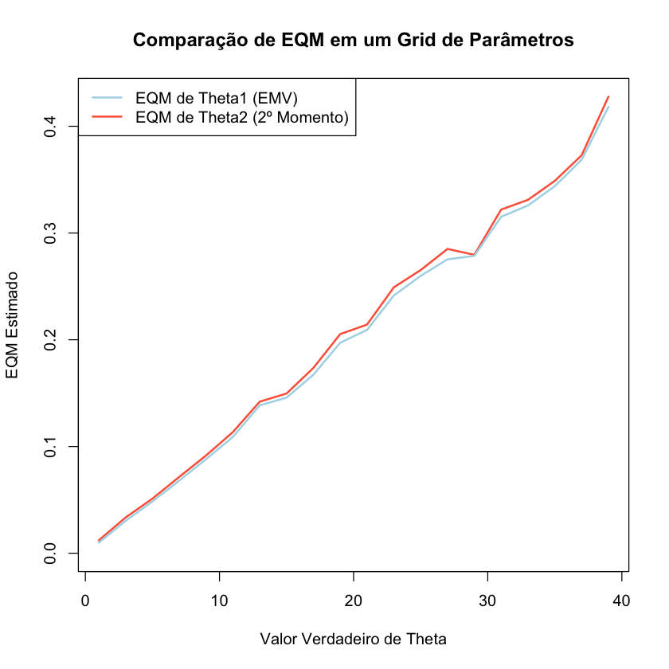

```r
# 1. Definição do Grid de parâmetros e outros parâmetros
set.seed(42)
n = 100
M = 1000 # Reduzimos M para a simulação do grid ser mais rápida
theta_grid = seq(1, 40, by = 2) # Grid de 1 a 40

# 2. Vetores para armazenar os EQMs calculados no grid
EQM1_grid = numeric(length(theta_grid))
EQM2_grid = numeric(length(theta_grid))

# 3. Loop sobre o grid de parâmetros
cat("Iniciando simulação no Grid...\n")
for (k in 1:length(theta_grid)) {

  theta0 = theta_grid[k] # Define o theta_verdadeiro para esta iteração

  # Vetores temporários para as estimativas
  theta1_temp = numeric(M)
  theta2_temp = numeric(M)

  # Loop interno de Monte Carlo (similar ao anterior)
  for (j in 1:M) {
    z = rpois(n, theta0)
    theta1_temp[j] = mean(z)
    media_z_quadrado = mean(z^2)
    theta2_temp[j] = (sqrt(4 * media_z_quadrado + 1) - 1) / 2
  }

  # Armazena o EQM para o theta0 atual
  EQM1_grid[k] = mean((theta1_temp - theta0)^2)
  EQM2_grid[k] = mean((theta2_temp - theta0)^2)
}
cat("Simulação no Grid concluída.\n")

# 4. Plotando os resultados do Grid
# Resetar layout de plotagem
par(mfrow = c(1, 1))

plot(theta_grid, EQM2_grid,
     type = "l", # 'l' para linha
     col = "tomato",
     lwd = 2,
     main = "Comparação de EQM em um Grid de Parâmetros",
     xlab = "Valor Verdadeiro de Theta",
     ylab = "EQM Estimado",
     ylim = c(0, max(EQM2_grid))) # Ajusta o eixo y

lines(theta_grid, EQM1_grid, col = "lightblue", lwd = 2)

# Legenda
legend("topleft",
       legend = c("EQM de Theta1 (EMV)", "EQM de Theta2 (2º Momento)"),
       col = c("lightblue", "tomato"),
       lwd = 2)
```

**Conclusão Final da Análise em Grid:** O gráfico final mostra claramente que a linha do EQM para `theta1` (azul) está consistentemente abaixo da linha do EQM para `theta2` (vermelho) para **todos os valores de $\theta$ testados no grid**. Isso nos dá uma confiança muito maior de que $\hat{\theta}_1 = \overline{Z}$ não é apenas melhor para um $\theta$ específico, mas é um estimador uniformemente superior em termos de EQM.

Este notebook agora reconstitui toda a lógica da sua aula, desde a definição dos estimadores, passando pela sua comparação empírica (EQM), até a verificação da teoria assintótica (TLC) e a robustez dessa comparação em diferentes cenários (Grid).

## 8. Verificação Prática com Variâncias Estimadas (Slutsky)

Até agora, para verificar o TLC, usamos a variância assintótica *teórica*, que depende do valor verdadeiro `theta0`. Na prática, `theta0` é desconhecido. O passo final é verificar se a teoria assintótica se mantém quando substituímos a variância teórica por uma **estimativa consistente**, como nos permite o **Teorema de Slutsky**.

Isso nos leva a uma **quantidade pivotal aproximada**, que é a base para a construção de intervalos de confiança e testes de hipóteses no mundo real.

### Simulação: Validando a Quantidade Pivotal

Vamos criar novas estatísticas padronizadas, `z1_practical` e `z2_practical`, onde o denominador é calculado usando as próprias estimativas `theta1_vetor` e `theta2_vetor`, em vez do `theta0` fixo.

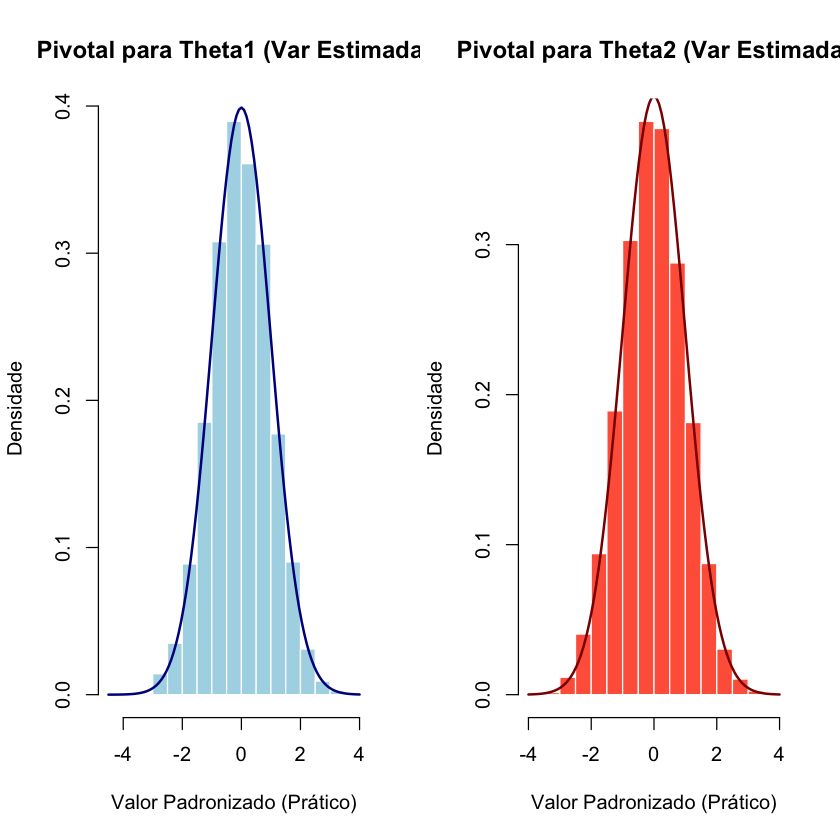

```r
# 1. Parâmetros e vetores de estimativas da simulação anterior
# Não precisamos re-rodar o loop, apenas reutilizar os resultados.
set.seed(42)
n = 100
theta0 = 10
# Assumimos que theta1_vetor e theta2_vetor já existem no ambiente
# a partir da simulação da Seção 6.

# 2. Cálculo das variâncias assintóticas ESTIMADAS
# Para cada uma das M simulações, calculamos uma variância diferente.
var_est_1 = theta1_vetor # Estimativa consistente de Var(Z) = theta
var_est_2 = (4*theta2_vetor^3 + 6*theta2_vetor^2 + theta2_vetor) / (1 + 2*theta2_vetor)^2

# 3. Padronização prática (usando variâncias estimadas)
z1_practical = sqrt(n) * (theta1_vetor - theta0) / sqrt(var_est_1)
z2_practical = sqrt(n) * (theta2_vetor - theta0) / sqrt(var_est_2)

# 4. Visualização
# Configura o layout para plotar 2 gráficos lado a lado
par(mfrow = c(1, 2))

# Histograma para a quantidade pivotal do estimador 1
hist(z1_practical,
     prob = TRUE,
     main = "Pivotal para Theta1 (Var Estimada)",
     xlab = "Valor Padronizado (Prático)",
     ylab = "Densidade",
     col = "lightblue",
     border = "white",
     breaks = 20)
curve(dnorm(x, 0, 1), add = TRUE, col = "darkblue", lwd = 2)

# Histograma para a quantidade pivotal do estimador 2
hist(z2_practical,
     prob = TRUE,
     main = "Pivotal para Theta2 (Var Estimada)",
     xlab = "Valor Padronizado (Prático)",
     ylab = "Densidade",
     col = "tomato",
     border = "white",
     breaks = 20)
curve(dnorm(x, 0, 1), add = TRUE, col = "darkred", lwd = 2)
```

## Conclusão Geral

Este notebook reconstituiu a análise completa de dois estimadores para o parâmetro da distribuição de Poisson, baseados no método dos momentos.

1. **Comparação Empírica:** A simulação de Monte Carlo mostrou que o estimador baseado no primeiro momento, $\hat{\theta}_1 = \overline{Z}$ (que também é o EMV), possui um **Erro Quadrático Médio (EQM) consistentemente menor** do que o estimador baseado no segundo momento, $\hat{\theta}_2$.
2. **Validação da Teoria Assintótica:** Demonstramos que o **Teorema do Limite Central para Estimadores** se aplica a ambos. As simulações confirmaram que as distribuições dos estimadores, quando padronizados com suas variâncias teóricas, convergem para uma Normal Padrão.
3. **Validação da Prática Inferencial:** A última simulação validou um resultado ainda mais poderoso. Graças ao **Teorema de Slutsky**, mostramos que mesmo quando padronizamos os estimadores com suas **variâncias estimadas** (o único cenário possível na prática), a convergência para a Normal Padrão se mantém.

Isso fecha o ciclo, conectando a teoria das funções de estimação e suas propriedades assintóticas com a sua aplicação prática na inferência estatística, tudo validado por meio de simulações de Monte Carlo.

# REVISÃO

## 1. Os Princípios Distintos de EMV e EMM

Como discutido, o Estimador de Máxima Verossimilhança (EMV) e o Estimador de Momentos (EMM) são derivados de princípios fundamentalmente diferentes:

- **EMV (Máxima Verossimilhança):** Busca o valor do parâmetro que maximiza a probabilidade (ou densidade) da amostra observada. Ele utiliza a informação completa da distribuição contida na **função de verossimilhança**. Sua filosofia é: "Qual valor de $\theta$ torna os dados que eu observei os mais prováveis?".
- **EMM (Momentos):** Busca o valor do parâmetro que iguala os momentos teóricos da população (como a média $E[X]$) aos seus correspondentes empíricos na amostra (como a média amostral $\overline{X}$). Ele utiliza uma informação parcial da distribuição. Sua filosofia é: "Qual valor de $\theta$ faz com que a média teórica do modelo seja igual à média que observei?".

Embora possam coincidir em certos casos (como na Poisson), eles não são, em geral, o mesmo. Um não está englobado no outro. Para evidenciar essa diferença, vamos analisar um caso em que eles produzem resultados distintos.

## 2. Estudo de Caso: A Distribuição Uniforme $U(0, \theta)$

Seja $Z_1, ..., Z_n$ uma amostra aleatória de uma população com distribuição Uniforme no intervalo $(0, \theta)$. A função densidade de probabilidade (f.d.p.) é:

$$f(z|\theta) = \frac{1}{\theta}, \quad \text{para } 0 < z < \theta$$

Vamos derivar os dois estimadores para $\theta$.

### Derivação do Estimador de Momentos (EMM)

1. **Primeiro Momento Populacional:** A esperança de uma $U(0, \theta)$ é $E_{\theta}(Z) = \frac{0 + \theta}{2} = \frac{\theta}{2}$.
2. **Primeiro Momento Amostral:** É a média amostral, $\overline{Z}$.
3. **Igualando os Momentos:** Igualamos o momento populacional ao amostral e resolvemos para $\theta$: $$\frac{\hat{\theta}_{MM}}{2} = \overline{Z} \implies \hat{\theta}_{MM} = 2\overline{Z}$$

### Derivação do Estimador de Máxima Verossimilhança (EMV)

1. **Função de Verossimilhança:** A verossimilhança da amostra $z_n$ é o produto das densidades: $$L(\theta|z_n) = \prod_{i=1}^{n} \frac{1}{\theta} = \left(\frac{1}{\theta}\right)^n$$ Esta função só é válida se **todas** as observações $z_i$ estiverem no intervalo $(0, \theta)$, o que significa que $\theta$ deve ser maior ou igual ao máximo valor observado na amostra, $Z_{(n)} = \max(Z_1, ..., Z_n)$.
2. **Maximização:** A função $L(\theta) = (1/\theta)^n$ é decrescente em $\theta$. Para maximizá-la, precisamos escolher o **menor valor possível para $\theta$** que ainda seja consistente com os dados. O menor valor que $\theta$ pode assumir é o máximo da amostra. $$\hat{\theta}_{MV} = Z_{(n)}$$

Claramente, $\hat{\theta}_{MM} = 2\overline{Z}$ e $\hat{\theta}_{MV} = Z_{(n)}$ são estimadores diferentes. Qual é melhor? Vamos usar uma simulação para comparar seus Erros Quadráticos Médios (EQM).

## 3. Simulação de Monte Carlo em R para Comparação

Vamos simular o processo para ver qual estimador se comporta melhor na prática.

```r
# 1. Parâmetros da simulação
set.seed(123)
n = 30       # Tamanho da amostra
M = 20000    # Número de réplicas
theta0 = 10  # Valor verdadeiro de theta

# 2. Vetores para armazenar as estimativas
theta_mv_vetor = numeric(M)
theta_mm_vetor = numeric(M)

# 3. Loop de Simulação
for (j in 1:M) {
  # Gerar uma amostra de uma população U(0, theta0)
  amostra = runif(n, min = 0, max = theta0)

  # Calcular e armazenar a estimativa de MV
  theta_mv_vetor[j] = max(amostra)

  # Calcular e armazenar a estimativa de Momentos
  theta_mm_vetor[j] = 2 * mean(amostra)
}

# 4. Cálculo do EQM estimado para cada estimador
EQM_mv = mean((theta_mv_vetor - theta0)^2)
EQM_mm = mean((theta_mm_vetor - theta0)^2)

# 5. Apresentação dos resultados
cat("Resultado da Simulação de Monte Carlo para U(0, theta)\n")
cat("------------------------------------------------------\n")
cat("Tamanho da Amostra (n):", n, "\n")
cat("Valor Verdadeiro (theta0):", theta0, "\n\n")
cat("EQM estimado para EMV (Máximo da amostra):", EQM_mv, "\n")
cat("EQM estimado para EMM (2 * Média):", EQM_mm, "\n")
```

```
Resultado da Simulação de Monte Carlo para U(0, theta)
------------------------------------------------------
Tamanho da Amostra (n): 30
Valor Verdadeiro (theta0): 10

EQM estimado para EMV (Máximo da amostra): 0.1984983
EQM estimado para EMM (2 * Média): 1.104658
```

## 4. Análise dos Resultados e Visualização

A simulação mostra que o **EQM do EMV é substancialmente menor** que o EQM do EMM. Isso sugere que, para a distribuição Uniforme, o máximo da amostra é um estimador superior (em termos de EQM) ao dobro da média amostral.

A visualização de suas distribuições amostrais nos ajuda a entender o porquê.

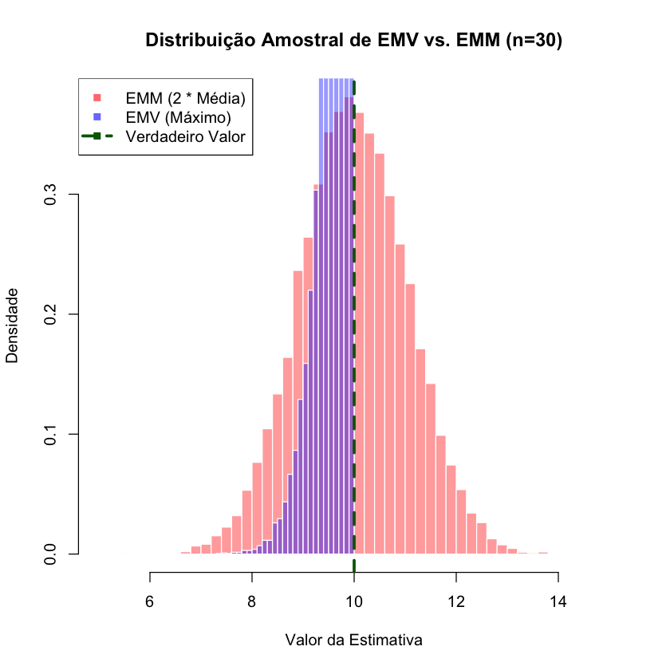

```r
# Gerando os histogramas para comparar
hist(theta_mm_vetor,
     prob = TRUE,
     main = "Distribuição Amostral de EMV vs. EMM (n=30)",
     xlab = "Valor da Estimativa",
     ylab = "Densidade",
     col = rgb(1, 0, 0, 0.4), # Vermelho ("tomato")
     border = "white",
     xlim = c(5, 15),
     breaks = 30)

hist(theta_mv_vetor,
     prob = TRUE,
     col = rgb(0, 0, 1, 0.4), # Azul
     border = "white",
     add = TRUE,
     breaks = 30)

# Adicionando uma linha vertical no valor verdadeiro
abline(v = theta0, col = "darkgreen", lwd = 3, lty = 2)

# Legenda
legend("topleft",
       legend = c("EMM (2 * Média)", "EMV (Máximo)", "Verdadeiro Valor"),
       col = c(rgb(1, 0, 0, 0.6), rgb(0, 0, 1, 0.6), "darkgreen"),
       pch = 15,
       lty = c(NA, NA, 2),
       lwd = c(NA, NA, 3))
```

**Interpretação do Gráfico:**

- **Estimador de Momentos (vermelho):** Sua distribuição é aproximadamente simétrica e centrada no valor verdadeiro $\theta_0 = 10$. Isso indica que o EMM é um estimador não-viesado, mas possui uma variância relativamente alta (a distribuição é "larga").
- **Estimador de Máxima Verossimilhança (azul):** Sua distribuição é assimétrica e concentrada logo à esquerda do valor verdadeiro. Isso nos mostra duas coisas:
  1. O EMV é **viesado** (em média, ele subestima o valor verdadeiro, já que o máximo da amostra nunca pode ser maior que $\theta_0$).
  2. Ele possui uma **variância muito pequena** (a distribuição é "estreita").
- **Comparação:** O baixo EQM do EMV vem do fato de que sua variância muito pequena compensa largamente o seu pequeno viés.

## 5. Conclusão Final

Este estudo de caso demonstra de forma conclusiva que **EMV e EMM são métodos distintos que podem levar a estimadores muito diferentes**. A simulação de Monte Carlo não apenas confirmou essa diferença, mas também nos permitiu comparar o desempenho dos estimadores através do EQM, mostrando que, para a distribuição Uniforme $U(0, \theta)$, o EMV é superior apesar de ser viesado.

Isso reforça a ideia de que cada método de estimação tem suas próprias características e o "melhor" estimador depende do critério de avaliação (EQM, viés, etc.) e do problema em questão.

## 1. Introdução: Funções de Estimação

Na estatística clássica, diversos métodos de estimação podem ser vistos através de uma lente unificada: o método das **Funções de Estimação**. Este framework generaliza tanto o Método de Máxima Verossimilhança (EMV) quanto o Método de Momentos (EMM).

## 2. EMV vs. EMM: Princípios Distintos

Apesar de poderem ser expressos como funções de estimação, o EMV e o EMM surgem de princípios diferentes.

### 2.1 O Caso da Coincidência: Família Exponencial

Para certas distribuições, como as da família exponencial de um parâmetro, o EMV e o EMM de primeira ordem podem coincidir.

Seja $Z_1, ..., Z_n$ uma amostra aleatória de $Z \sim \text{Pois}(\theta)$.

Seja $Z_1, ..., Z_n$ uma amostra aleatória de $Z \sim \text{Ber}(\theta)$.

### 2.2 O Caso da Divergência: Uniforme $U(0, \theta)$

Para mostrar que não são a mesma classe de estimadores, consideramos o caso de $Z \sim U(0, \theta)$.

- **EMV:** A verossimilhança $L(\theta) = (1/\theta)^n$ é maximizada quando $\theta$ é o menor valor possível, que é o máximo da amostra: $\hat{\theta}_{MV} = Z_{(n)}$.
- **EMM de 1ª Ordem:** O momento populacional $E_{\theta}(Z) = \theta/2$ é igualado à média amostral $\overline{Z}$, resultando em $\hat{\theta}_{MM} = 2\overline{Z}$.

Aqui, os estimadores são claramente diferentes. Vamos usar uma simulação para comparar seu desempenho.

### Simulação: Comparando EQM para a Distribuição Uniforme

```r
# Parâmetros da simulação
set.seed(123)
n = 30
M = 20000
theta0 = 10

# Vetores para armazenar as estimativas
theta_mv_vetor = numeric(M)
theta_mm_vetor = numeric(M)

# Loop de Simulação
for (j in 1:M) {
  amostra = runif(n, min = 0, max = theta0)
  theta_mv_vetor[j] = max(amostra)
  theta_mm_vetor[j] = 2 * mean(amostra)
}

# Cálculo do EQM estimado
EQM_mv = mean((theta_mv_vetor - theta0)^2)
EQM_mm = mean((theta_mm_vetor - theta0)^2)

# Apresentação dos resultados
cat("EQM estimado para EMV (Máximo):", EQM_mv, "\n")
cat("EQM estimado para EMM (2 * Média):", EQM_mm, "\n")
```

```
EQM estimado para EMV (Máximo): 0.1984983
EQM estimado para EMM (2 * Média): 1.104658
```

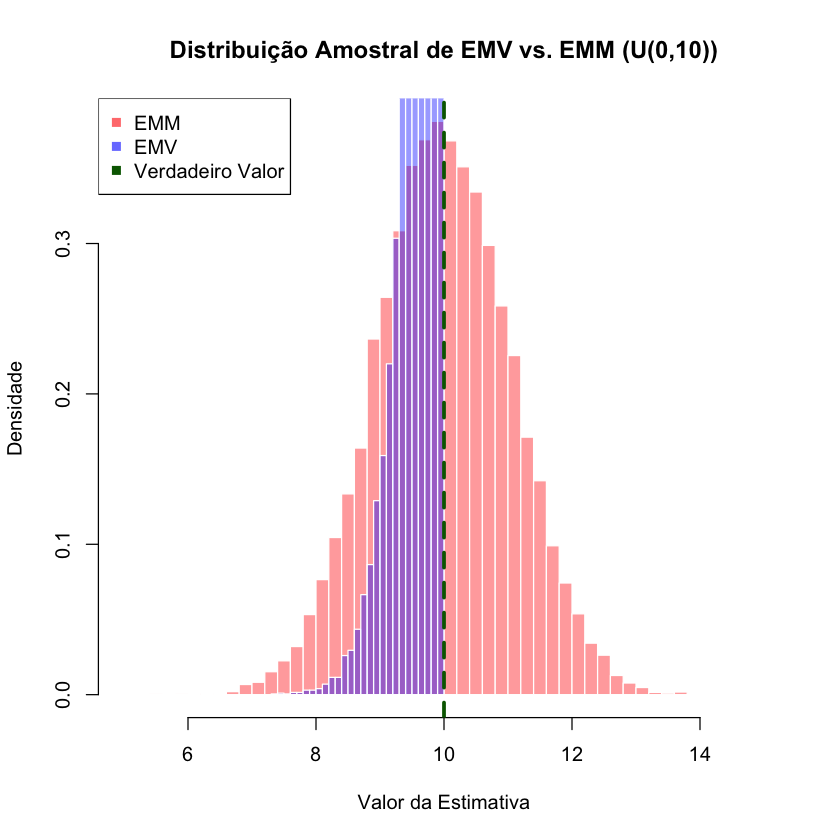

```r
# Visualização das distribuições amostrais
hist(theta_mm_vetor, prob = TRUE, main = "Distribuição Amostral de EMV vs. EMM (U(0,10))",
     xlab = "Valor da Estimativa", ylab = "Densidade", col = rgb(1, 0, 0, 0.4),
     border = "white", xlim = c(5, 15), breaks = 30)
hist(theta_mv_vetor, prob = TRUE, col = rgb(0, 0, 1, 0.4), border = "white", add = TRUE, breaks = 30)
abline(v = theta0, col = "darkgreen", lwd = 3, lty = 2)
legend("topleft", legend = c("EMM", "EMV", "Verdadeiro Valor"),
       col = c(rgb(1, 0, 0, 0.6), rgb(0, 0, 1, 0.6), "darkgreen"), pch = 15)
```

**Análise:** A simulação mostra que o EMV tem um EQM muito menor. O gráfico revela que, embora o EMV seja viesado (sua distribuição está à esquerda do valor verdadeiro), sua variância é tão pequena que compensa o viés, resultando em um desempenho superior.

## 3. Análise Assintótica e Verificação Prática

$$\sqrt{n}(\hat{\theta}_{n}-\theta)\xrightarrow{D} N(0, B(\theta))$$

$$\sqrt{n}A_{n}(\hat{\theta}_{n})^{-1/2}(\hat{\theta}_{n}-\theta)\xrightarrow{D} N(0,I)$$

### Simulação: Verificando a Quantidade Pivotal para a Poisson

Vamos voltar ao caso da Poisson e comparar os dois estimadores (EMM1/EMV e EMM2). Verificaremos se suas versões padronizadas *práticas* (com variância estimada) convergem para uma Normal Padrão, como previsto pela teoria.

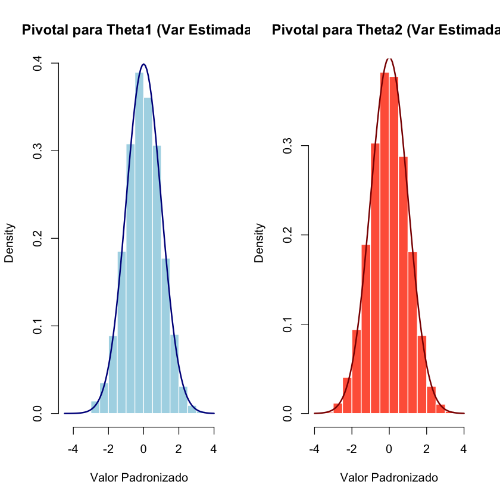

```r
# Verificação de Slutsky
# Parâmetros da simulação
set.seed(42)
n = 100
M = 10000
theta0 = 10

# Vetores de estimativas
theta1_vetor = numeric(M)
theta2_vetor = numeric(M)

# Loop principal
for (j in 1:M) {
  z = rpois(n, theta0)
  theta1_vetor[j] = mean(z)
  media_z_quadrado = mean(z^2)
  theta2_vetor[j] = (sqrt(4 * media_z_quadrado + 1) - 1) / 2
}

# Cálculo das variâncias assintóticas ESTIMADAS
var_est_1 = theta1_vetor # Estimativa consistente de Var(Z) = theta
var_est_2 = (4*theta2_vetor^3 + 6*theta2_vetor^2 + theta2_vetor) / (1 + 2*theta2_vetor)^2

# Padronização prática (usando variâncias estimadas)
z1_practical = sqrt(n) * (theta1_vetor - theta0) / sqrt(var_est_1)
z2_practical = sqrt(n) * (theta2_vetor - theta0) / sqrt(var_est_2)

# Visualização
par(mfrow = c(1, 2))
hist(z1_practical, prob = TRUE, main = "Pivotal para Theta1 (Var Estimada)",
     xlab = "Valor Padronizado", col = "lightblue", border = "white", breaks = 20)
curve(dnorm(x, 0, 1), add = TRUE, col = "darkblue", lwd = 2)

hist(z2_practical, prob = TRUE, main = "Pivotal para Theta2 (Var Estimada)",
     xlab = "Valor Padronizado", col = "tomato", border = "white", breaks = 20)
curve(dnorm(x, 0, 1), add = TRUE, col = "darkred", lwd = 2)
```

**Análise:** Os histogramas das distribuições empíricas se ajustam perfeitamente à curva da Normal Padrão. Isso é uma comprovação via simulação de que a teoria assintótica, incluindo a aplicação do Teorema de Slutsky, descreve com precisão o comportamento dos estimadores, validando seu uso para construir intervalos de confiança e testes de hipóteses na prática.